# VEGANScreener + metabolomics

Q0: Associations of metabolome profile with various external variables.

**This script explores patterns in the metabolome profiles of vegans.**

This first part of the analysis (Q0) presents exploratory data analysis describing the study cohort:

- descriptive statistics
- PCA plots, color-coded by different external variables
- correlations between individual PCs and different external variables
- PERMANOVA

# 1 Import

```r
metadata_df <- read.table(
  file = "../../data/preprocessed/metadata_preprocessed_v3.tsv",
  header = TRUE)

spca_integrated_df <-  read.table(
  file = "../../data/preprocessed/metabolomics/spca_integrated_vegans_INT_v3.tsv",
  check.names = FALSE)

pdi_df <- read.table(
  file = "../../data/preprocessed/dietary/pdi/pdi_avg_residuals_scaled_v3.tsv",
  check.names = FALSE,
  header = TRUE) %>%
  dplyr::select(study_id,pdi_avg,hpdi_avg,updi_avg) %>%
  dplyr::mutate(
    pdi_avg = pdi_avg + 30,
    hpdi_avg = hpdi_avg + 30,
    updi_avg = updi_avg + 30)

metadata_df <- merge(metadata_df,pdi_df,by = "study_id",all.x = TRUE)
```

**Scaling** — when metadata columns are used as covariates, they need to be scaled so that each has a mean of 0 and a standard deviation of 1.

```r
metadata_scaled_df <- metadata_df
metadata_scaled_df[,-c(1,3,5,6,8)] <- apply(metadata_df[,-c(1,3,5,6,8)],2,scale)
metadata_scaled_df <- metadata_scaled_df %>%
  mutate(sex=as.factor(sex),
         country=as.factor(country),
         group=as.factor(group),
         diet_supplements=as.factor(diet_supplements))
```

# 2 Descriptive statistics

```r
metadata_df %>% dplyr::group_by(country,sex) %>% dplyr::count()
```

```
# A tibble: 10 × 3
# Groups:   country, sex [10]
   country sex       n
   <chr>   <chr> <int>
 1 BE      F        54
 2 BE      M        28
 3 CH      F        23
 4 CH      M        20
 5 CZ      F        50
 6 CZ      M        41
 7 DE      F        51
 8 DE      M        47
 9 ES      F        28
10 ES      M        15
```

Basic plots showing the distribution of selected variables:

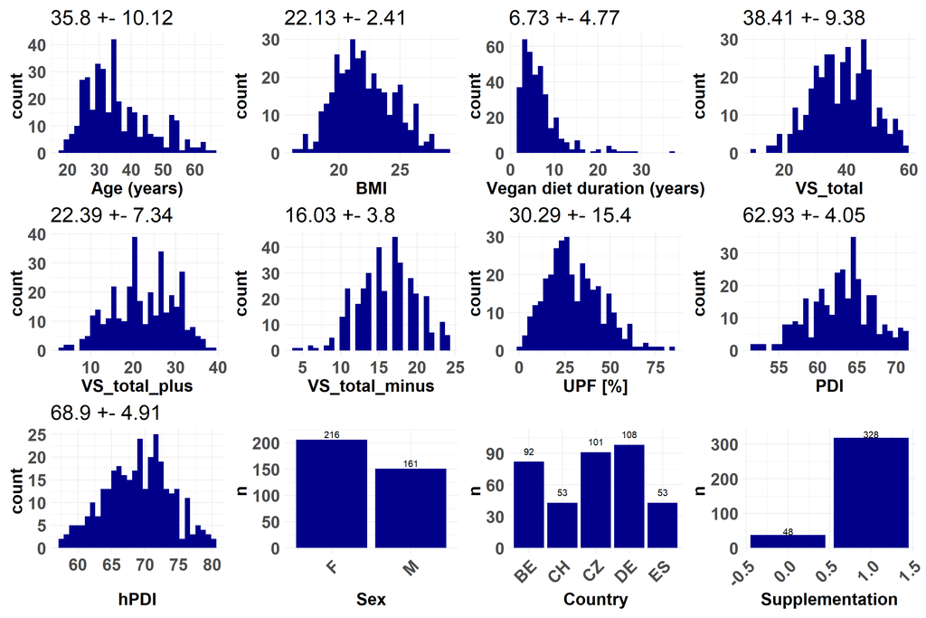

```r
plot_list <- list()
name <- c("Age (years)","BMI","Vegan diet duration (years)","VS_total",
          "VS_total_plus","VS_total_minus",
          "UPF [%]","PDI","hPDI")
i <- 1
for (col in c("age","bmi","vegan_duration","VS_total","VS_total_plus","VS_total_minus", "UPF_perc_avg",
              "pdi_avg","hpdi_avg")){
  p <- ggplot(metadata_df) +
    geom_histogram(aes(x=!!sym(col)),fill="darkblue") +
    theme_minimal() +
    theme(axis.title = element_text(face="bold",size=20),
          axis.text=element_text(face="bold",size=20),
          title = element_text(face = "plain",size=20)) +
    xlab(name[i]) +
    ggtitle(paste(round(mean(metadata_df[,col],na.rm = TRUE),2),"+-", round(sd(metadata_df[,col],na.rm = TRUE),2)))

  plot_list[[length(plot_list)+1]] <- p
  i <- i + 1

}
i <- 1
name <- c("Sex","Country","Supplementation")
for (col in c("sex","country","diet_supplements")){
  p <- ggplot(metadata_df) +
        theme_minimal() +
     theme(axis.title = element_text(face="bold",size=20),
          axis.text=element_text(face="bold",size=20),
          axis.text.x=element_text(angle = 45,hjust = 1)) +
    stat_count(aes(x=!!sym(col)),fill="darkblue") +
    xlab(name[i]) +
  geom_text(data=metadata_df %>%
              dplyr::group_by(!!sym(col)) %>% dplyr::count() %>%
              dplyr::mutate(n=n+10), aes(x=!!sym(col),y=n,label=n))

  plot_list[[length(plot_list)+1]] <- p

  i <- i+1
}

wrap_plots(plot_list)
```

# 3 Table 1

Generating Table 1: baseline characteristics of the study participants.

```r
# Define variables
continuous_vars <- c("age", "bmi", "vegan_duration",
                     "VS_total","VS_total_plus","VS_total_minus",
                     "pdi_avg","hpdi_avg", "UPF_perc_avg")

categorical_vars <- c("sex", "diet_supplements")  # add more if needed

# stratify by country
strata_var <- "country"  # set to NULL if not stratifying

# Overall (non-stratified)
table_overall <- CreateTableOne(vars = c(continuous_vars, categorical_vars),
                                data = metadata_df,
                                factorVars = categorical_vars,
                                test = FALSE)

# Stratified by country
table_strat <- CreateTableOne(vars = c(continuous_vars, categorical_vars),
                              strata = strata_var,
                              data = metadata_df,
                              factorVars = categorical_vars,
                              test = FALSE)

# Combine into one table for display
# Extract as data frames
df_overall <- print(table_overall, showAllLevels = TRUE, quote = FALSE, noSpaces = TRUE, printToggle = FALSE)
df_strat <- print(table_strat, showAllLevels = TRUE, quote = FALSE, noSpaces = TRUE, printToggle = FALSE)

# Combine overall + stratified
table_final <- cbind(Overall = df_overall, df_strat)

# Display
knitr::kable(table_final, caption = "Table 1. Baseline characteristics of study participants")
```

Table 1. Baseline characteristics of study participants

|  | level | Overall | level | BE | CH | CZ | DE | ES |
| --- | --- | --- | --- | --- | --- | --- | --- | --- |
| n |  | 357 |  | 82 | 43 | 91 | 98 | 43 |
| age (mean (SD)) |  | 35.80 (10.12) |  | 37.65 (9.08) | 37.49 (11.38) | 32.97 (5.85) | 37.15 (11.95) | 33.49 (11.82) |
| bmi (mean (SD)) |  | 22.13 (2.41) |  | 22.26 (2.24) | 21.77 (1.92) | 22.05 (2.63) | 22.49 (2.42) | 21.60 (2.57) |
| vegan_duration (mean (SD)) |  | 6.73 (4.77) |  | 7.66 (5.52) | 5.92 (5.44) | 7.12 (3.46) | 6.32 (5.05) | 5.84 (4.03) |
| VS_total (mean (SD)) |  | 38.41 (9.38) |  | 34.07 (8.95) | 40.81 (8.07) | 36.47 (9.95) | 42.96 (8.18) | 38.02 (7.79) |
| VS_total_plus (mean (SD)) |  | 22.39 (7.34) |  | 19.84 (7.33) | 23.81 (7.11) | 21.21 (7.94) | 25.61 (6.16) | 20.93 (5.90) |
| VS_total_minus (mean (SD)) |  | 16.03 (3.80) |  | 14.24 (3.56) | 17.00 (3.11) | 15.26 (4.18) | 17.35 (3.16) | 17.09 (3.75) |
| pdi_avg (mean (SD)) |  | 62.93 (4.05) |  | 63.26 (3.43) | 64.47 (3.76) | 61.92 (4.12) | 63.71 (4.08) | 60.75 (4.09) |
| hpdi_avg (mean (SD)) |  | 68.90 (4.91) |  | 67.62 (5.06) | 68.60 (4.81) | 68.37 (4.73) | 70.02 (4.71) | 69.94 (4.93) |
| UPF_perc_avg (mean (SD)) |  | 30.29 (15.40) |  | 43.04 (15.33) | 28.69 (14.77) | 28.79 (14.05) | 25.04 (12.43) | 22.15 (9.37) |
| sex (%) | F | 206 (57.7) | F | 54 (65.9) | 23 (53.5) | 50 (54.9) | 51 (52.0) | 28 (65.1) |
|  | M | 151 (42.3) | M | 28 (34.1) | 20 (46.5) | 41 (45.1) | 47 (48.0) | 15 (34.9) |
| diet_supplements (%) | 0 | 38 (10.7) | 0 | 13 (15.9) | 3 (7.0) | 15 (16.7) | 5 (5.1) | 2 (4.7) |
|  | 1 | 318 (89.3) | 1 | 69 (84.1) | 40 (93.0) | 75 (83.3) | 93 (94.9) | 41 (95.3) |

```r
write.xlsx(table_final,"../results/vegan/Table1.xlsx",rowNames=TRUE)
```

```r
skim(metadata_df)
```

Data summary

| Name | metadata_df |
| --- | --- |
| Number of rows | 357 |
| Number of columns | 15 |
| _______________________ |  |
| Column type frequency: |  |
| character | 3 |
| numeric | 12 |
| ________________________ |  |
| Group variables | None |

**Variable type: character**

| skim_variable | n_missing | complete_rate | min | max | empty | n_unique | whitespace |
| --- | --- | --- | --- | --- | --- | --- | --- |
| sex | 0 | 1 | 1 | 1 | 0 | 2 | 0 |
| country | 0 | 1 | 2 | 2 | 0 | 5 | 0 |
| group | 0 | 1 | 2 | 2 | 0 | 1 | 0 |

**Variable type: numeric**

| skim_variable | n_missing | complete_rate | mean | sd | p0 | p25 | p50 | p75 | p100 | hist |
| --- | --- | --- | --- | --- | --- | --- | --- | --- | --- | --- |
| study_id | 0 | 1.00 | 27515.57 | 12858.82 | 11001.00 | 21008.00 | 31006.00 | 31099.00 | 51046.00 | ▇▇▇▃▃ |
| age | 0 | 1.00 | 35.80 | 10.12 | 18.00 | 28.00 | 34.00 | 42.00 | 66.00 | ▃▇▃▂▁ |
| bmi | 0 | 1.00 | 22.13 | 2.41 | 16.42 | 20.37 | 21.91 | 23.78 | 28.88 | ▂▇▇▅▁ |
| vegan_duration | 0 | 1.00 | 6.73 | 4.77 | 2.00 | 3.58 | 5.58 | 8.08 | 37.00 | ▇▂▁▁▁ |
| diet_supplements | 1 | 1.00 | 0.89 | 0.31 | 0.00 | 1.00 | 1.00 | 1.00 | 1.00 | ▁▁▁▁▇ |
| VS_total | 0 | 1.00 | 38.41 | 9.38 | 10.00 | 32.00 | 39.00 | 45.00 | 59.00 | ▁▃▇▇▂ |
| VS_total_plus | 1 | 1.00 | 22.39 | 7.34 | 3.00 | 17.00 | 22.00 | 28.00 | 39.00 | ▁▅▇▇▂ |
| VS_total_minus | 0 | 1.00 | 16.03 | 3.80 | 4.00 | 13.00 | 16.00 | 19.00 | 24.00 | ▁▃▇▇▃ |
| UPF_perc_avg | 29 | 0.92 | 30.29 | 15.40 | 0.00 | 19.24 | 27.55 | 40.13 | 84.03 | ▃▇▆▂▁ |
| pdi_avg | 35 | 0.90 | 62.93 | 4.05 | 51.75 | 60.25 | 63.38 | 65.44 | 71.25 | ▁▃▆▇▂ |
| hpdi_avg | 35 | 0.90 | 68.90 | 4.91 | 57.50 | 65.50 | 69.25 | 72.25 | 80.25 | ▂▆▇▆▂ |
| updi_avg | 35 | 0.90 | 63.10 | 4.91 | 51.75 | 59.75 | 62.75 | 66.50 | 74.50 | ▂▆▇▆▂ |

# 4 Metabolites

```r
lcms_df <- read.table(
  file = "../../data/preprocessed/metabolomics/lc_ms_preprocessed_INT_v3.tsv",
  check.names = FALSE)

nmr_df <- read.table(
  file = "../../data/preprocessed/metabolomics/nmr_preprocessed_INT_v3.tsv",
  check.names = FALSE)

common_samples <- Reduce(intersect,
                         list(rownames(lcms_df),
                              rownames(nmr_df),
                              metadata_df$study_id))

lcms_df <- lcms_df[common_samples,]
nmr_df <- nmr_df[common_samples,]

dim(lcms_df)
```

```
[1] 357  50
```

```r
dim(nmr_df)
```

```
[1] 357  25
```

# 5 PERMANOVA

Testing each variable individually to quantify how much variance it explains in the serum metabolome profile.

```r
vars_to_test <- c("sex","bmi", "age", "VS_total","VS_total_plus","VS_total_minus", "vegan_duration","country", "diet_supplements","UPF_perc_avg","pdi_avg","hpdi_avg")

adonis_result_all <- data.frame(Var=NA,
                                Df=NA,
                                SumOfSqs=NA,
                                R2=NA,
                                `F`=NA,
                                `Pr(>F)`=NA,
                                check.names = FALSE)
for (var in vars_to_test){
  metadata_sub_df <- metadata_scaled_df %>% dplyr::select(all_of(c("study_id",var))) %>% drop_na()
  sub_spca <- spca_integrated_df[as.character(metadata_sub_df$study_id),]
  message(var,": ",nrow(sub_spca))
  # Create Euclidean distance matrix
  dist_mat <- vegdist(sub_spca,
                    method = "euclidean")

  # Test
  set.seed(123)
  adonis_result <- adonis2(
  as.formula(paste0("dist_mat ~ ", var)),
  data = metadata_sub_df ,
  permutations = 999,
  by="margin")

  adonis_result_all <- rbind(adonis_result_all,as.data.frame(adonis_result)[1,] %>%
                               rownames_to_column("Var"))
}


adonis_result_all$adjusted_p <- p.adjust(adonis_result_all$`Pr(>F)`,method = "BH")

adonis_result_all <- adonis_result_all[-1,]
print(adonis_result_all)
```

```
                Var Df   SumOfSqs          R2          F Pr(>F)  adjusted_p
2               sex  1 1103.48663 0.056240281 21.1550666  0.001 0.001333333
3               bmi  1  288.04454 0.014680473  5.2892161  0.001 0.001333333
4               age  1  257.30243 0.013113671  4.7172132  0.001 0.001333333
5          VS_total  1  579.55241 0.029537458 10.8049484  0.001 0.001333333
6     VS_total_plus  1  430.39017 0.021961929  7.9491005  0.001 0.001333333
7    VS_total_minus  1  521.02148 0.026554372  9.6839533  0.001 0.001333333
8    vegan_duration  1   45.44022 0.002315906  0.8240549  0.652 0.652000000
9           country  4 1956.27501 0.099703478  9.7455737  0.001 0.001333333
10 diet_supplements  1  134.44963 0.006867436  2.4478831  0.007 0.008400000
11     UPF_perc_avg  1  391.06232 0.021716295  7.2366657  0.001 0.001333333
12          pdi_avg  1   98.67836 0.005572984  1.7933492  0.033 0.036000000
13         hpdi_avg  1  460.89369 0.026029549  8.5520621  0.001 0.001333333
```

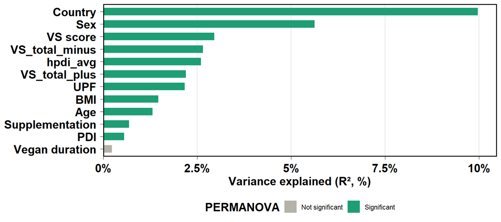

```r
# Significance grouping
adonis_result_all$significance <- ifelse(
  adonis_result_all$adjusted_p < 0.05, "Significant", "Not significant"
)

# Order by R2 ascending (so largest appears at top in coord_flip)
adonis_result_all$Var <- factor(
  adonis_result_all$Var,
  levels = adonis_result_all$Var[order(adonis_result_all$R2)]
)

# Plot
p <- ggplot(adonis_result_all, aes(x = Var, y = R2 * 100, fill = significance)) +
  geom_col(width = 0.6) +
  coord_flip() +
  scale_fill_manual(
    values = c("Significant" = "#1D9E75", "Not significant" = "#B4B2A9"),
    name = "PERMANOVA"
  ) +
  scale_y_continuous(
    labels = function(x) paste0(x, "%"),
    expand = expansion(mult = c(0, 0.05))
  ) +
  labs(
    x = NULL,
    y = "Variance explained (R², %)"
  )

p <- ggtheme(p) +
  theme(axis.text.x = element_text(face="bold",size=15),
        axis.text.y = element_text(face="bold",size=15),
        panel.grid.major.x = element_line(color = "grey90", linewidth = 0.4),
        title = element_text(face="bold",size=15),
        legend.position = "bottom") + scale_x_discrete(labels = c("country" = "Country",
                                  "VS_total" = "VS score",
                                  "sex" = "Sex",
                                  "UPF_perc_avg" = "UPF",
                                  "age" = "Age",
                                  "bmi" = "BMI",
                                  "diet_supplements" = "Supplementation",
                                  "vegan_duration" = "Vegan duration",
                                  "pdi_avg" = "PDI"
                                  ))

p
```

```r
f <- p
save(f,file="../results/vegan/figures/F2a_permanovaVar.RData")
```

# 6 Correlations with PCs

The sPCA dataset was created by concatenating the LC-MS and NMR datasets and applying the mixOmics::spca() function. See the preprocessing script for details.

mixOmics::spca() performs **sparse Principal Component Analysis (sPCA)**, which works like regular PCA but adds a sparsity constraint so that only a subset of variables contributes to each component. The degree of sparsity is controlled by a penalization term, which makes the components easier to interpret because irrelevant or noisy variables are given loadings of zero.

```r
metadata_analysis_df <- metadata_df %>%
  dplyr::select(study_id, VS_total,VS_total_plus,VS_total_minus, age, bmi, sex, country,
                vegan_duration, diet_supplements,UPF_perc_avg,pdi_avg,hpdi_avg) %>%
  column_to_rownames("study_id")

cor_results <- corr_with_pcs(spca_integrated_df,metadata_analysis_df)

### Filter significant correlations (p < 0.05)
df_sig <- cor_results %>%
  filter(is.finite(rho), pvalue < 0.05)
df_sig$var1 <- factor(df_sig$var1, levels = names(spca_integrated_df))
```

The plot below shows Spearman correlations between the individual PCs of the sPCA metabolome dataset and various external variables. The strongest associations appear with **sex**, individual **countries**, **VS_total**, and **bmi**. These variables are explored in more detail in other scripts.

The very strongest signal comes from individual **countries**, **VS_total**, and **sex**.

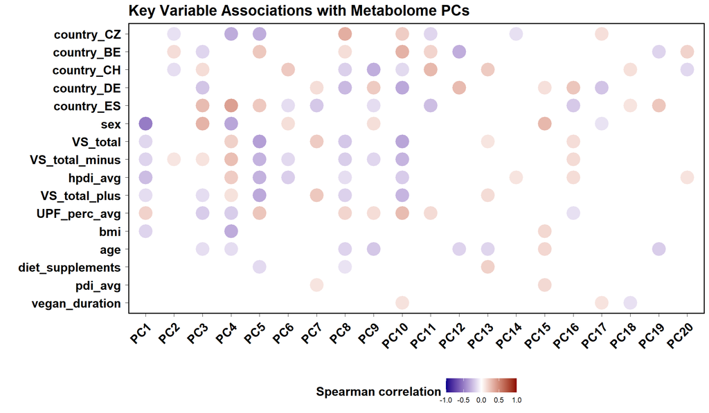

```r
meta_order <- df_sig %>%
  group_by(var2) %>%
  dplyr::summarize(max_abs_rho = max(sum(abs(rho)), na.rm = TRUE)) %>%
  arrange((max_abs_rho)) %>%
  pull(var2)

meta_order <- c(levels(adonis_result_all$Var)[-length(adonis_result_all$Var)],
                "country_ES","country_DE","country_CH","country_BE",
                "country_CZ")

df_sig$var2 <- factor(df_sig$var2, levels = meta_order)

p <- ggplot(df_sig, aes(x = var1, y = var2, fill = rho)) +
  geom_point(shape = 21,size=8,color="white") +
  scale_fill_gradient2(

    low = "darkblue",mid = "white",high = "darkred", midpoint = 0, name = "Spearman correlation",limits = c(-1, 1)) +
  labs(
    x = "",
    y = "",
    title = "Key Variable Associations with Metabolome PCs")

p <- ggtheme(p) +
  theme(axis.text.x = element_text(face="bold",size=15,angle=45,hjust=1),
        axis.text.y = element_text(face="bold",size=15),
        title = element_text(face="bold",size=15),
        legend.position = "bottom")

p
```

```r
f <- p
save(f,file="../results/vegan/figures/F2b_PcaCorr.RData")
```

# 7 PCA and colored metadata

The strongest pattern is seen with the **sex** variable, consistent with the correlation plot above.

**PC1 vs PC2**

```r
plot_list <- list()
for (col in c("sex","country","age","bmi","VS_total","vegan_duration","UPF_perc_avg","pdi_avg")){
  p <- pca_plot(spca_integrated_df,
              metadata_df,
              color_col = col,
              perform_pca = FALSE)

  p <- ggtheme(p)

  plot_list[[length(plot_list)+1]] <- p
}


a12 <- wrap_plots(plot_list)
```

**PC1 vs PC3**

```r
plot_list <- list()
for (col in c("sex","country","age","bmi","VS_total","vegan_duration","UPF_perc_avg","pdi_avg")){
  p <- pca_plot(spca_integrated_df,
              metadata_df,
              color_col = col,
              perform_pca = FALSE,
              axis=c("PC1","PC3"))

  p <- ggtheme(p)

  plot_list[[length(plot_list)+1]] <- p
}


a13 <- wrap_plots(plot_list)
```

**PC2 vs PC3**

```r
plot_list <- list()
for (col in c("sex","country","age","bmi","VS_total","vegan_duration","UPF_perc_avg","pdi_avg")){
  p <- pca_plot(spca_integrated_df,
              metadata_df,
              color_col = col,
              perform_pca = FALSE,
              axis=c("PC2","PC3"))

  p <- ggtheme(p)
  plot_list[[length(plot_list)+1]] <- p
}


a23 <- wrap_plots(plot_list)
```

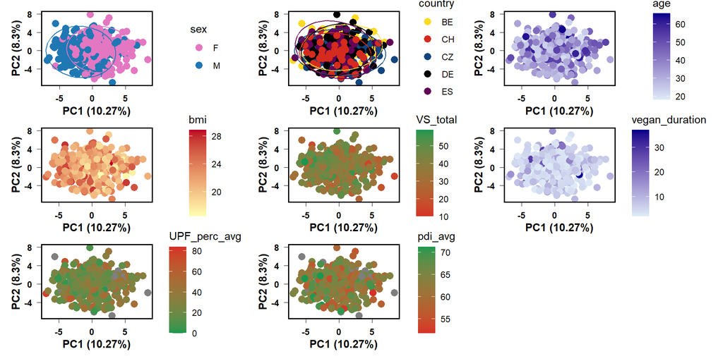

```r
a12
```

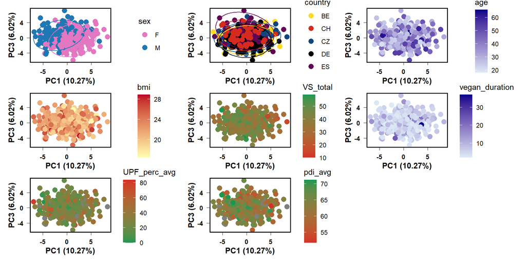

```r
a13
```

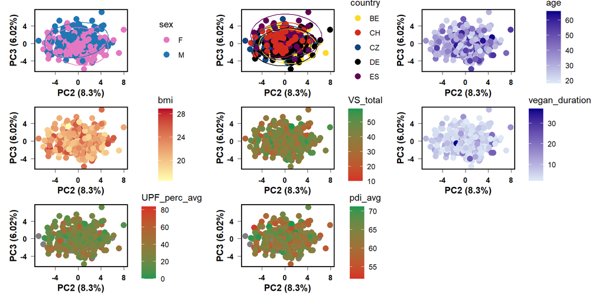

```r
a23
```